# Analysis on Advertisements in TV

Ashwin Ayyasamy Elamurugu

## Introduction:

We have two datasets —  
1. **Sessions:** user session data with ad-viewing information  
2. **Logos:** information on brands in ads along with info on users who viewed it

**Goal:** To uncover insights on how users interact with ads, if brands are visible to users (brand prominence), and more!

```r
sessions <- read_tsv("~/Desktop/sessions.tsv")
logos <- read_tsv("~/Desktop/logos.tsv")
query <- "SELECT l.*,
          count(DISTINCT s.household_id) as number_households
   FROM logos l
   LEFT JOIN sessions s ON l.network_group_id = s.network_group_id
          AND l.logo_occurrence_time_utc BETWEEN s.session_start_utc AND s.session_end_utc
   GROUP BY l.logo_occurrence_time_utc, l.network_group_id, l.brand_id
   "
data <- sqldf(query)

str(data)
```

```
## 'data.frame':    20000 obs. of  10 variables:
##  $ date_utc                : Date, format: "2019-07-14" "2019-07-14" ...
##  $ logo_occurrence_time_utc: POSIXct, format: "2019-07-14 16:00:00" "2019-07-14 16:00:00" ...
##  $ network_group_id        : chr  "bbc_america" "cbs_sports_network" "cbs_sports_network" "cnbc" ...
##  $ brand_id                : chr  "bbc" "cbs" "red_bull" "nbc" ...
##  $ number_logos_on_screen  : num  1 2 1 1 2 1 1 2 3 3 ...
##  $ on_screen_duration      : num  1 1172 5 6 720 ...
##  $ brand_prominence        : num  18.08 23.67 6.67 38.35 42.42 ...
##  $ show_display_name       : chr  "Escape Plan" "World TeamTennis" "World TeamTennis" "Shark Tank" ...
##  $ show_genre              : chr  "Other" "Other" "Other" "Reality" ...
##  $ number_households       : int  711 16 16 1083 2168 954 974 2899 437 437 ...
```

```r
head(data)
```

```
##     date_utc logo_occurrence_time_utc   network_group_id       brand_id
## 1 2019-07-14      2019-07-14 16:00:00        bbc_america            bbc
## 2 2019-07-14      2019-07-14 16:00:00 cbs_sports_network            cbs
## 3 2019-07-14      2019-07-14 16:00:00 cbs_sports_network       red_bull
## 4 2019-07-14      2019-07-14 16:00:00               cnbc            nbc
## 5 2019-07-14      2019-07-14 16:00:00                cnn            cnn
## 6 2019-07-14      2019-07-14 16:00:00     comedy_central comedy_central
##   number_logos_on_screen on_screen_duration brand_prominence
## 1                      1                  1        18.084069
## 2                      2               1172        23.673930
## 3                      1                  5         6.670645
## 4                      1                  6        38.345436
## 5                      2                720        42.420678
## 6                      1                  8        31.833365
##               show_display_name show_genre number_households
## 1                   Escape Plan      Other               711
## 2              World TeamTennis      Other                16
## 3              World TeamTennis      Other                16
## 4                    Shark Tank    Reality              1083
## 5 CNN Newsroom With Ana Cabrera       News              2168
## 6                    The Office     Comedy               954
```

# Data Cleaning:

1. Converted character columns to factoral Variables
2. Number of Logos on Screen and On Screen Duration variables have unevenly distributed levels so combined levels 3. with less than 1% observations of the level with highest number of samples into one
3. No work on missing values or transformations was necessary

```r
#Handling character columns with values that have very few observations
attach(data)
# table(data$number_logos_on_screen)
# table(data$on_screen_duration)
data['modified_number_logos_on_screen'] <- factor(ifelse(number_logos_on_screen > 1, '2+', number_logos_on_screen))
data['modified_on_screen_duration'] <- factor(ifelse(on_screen_duration > 10, '11+', on_screen_duration))
data$modified_on_screen_duration <- factor(data$modified_on_screen_duration,
                                              levels(data$modified_on_screen_duration)[c(1,4:11,2,3)])

#Converting character columns to factor
factor_cols <- c('network_group_id', 'brand_id', 'show_display_name', 'show_genre')
data[factor_cols] <- lapply(data[factor_cols], factor)
detach(data)
```

# Brand Related Analysis

##### 1. Which brands have the “most valuable” logo placement in this dataset? Which brands logos’ were seen by the most viewers?

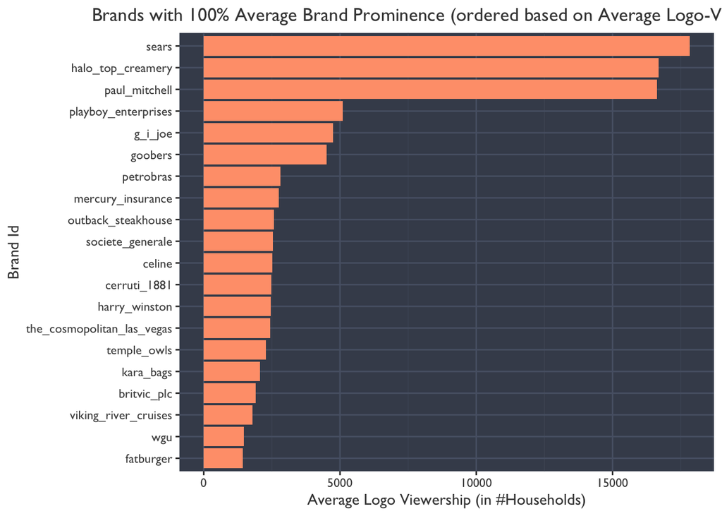

```r
attach(data)
brand_tbl <- data %>%
  group_by(brand_id) %>%
  summarise(mean_brand_prominence = mean(brand_prominence),
         mean_number_households = mean(number_households))  # Taking Means because we are interested in brands that consistently have the best 'logo placement'

valuable_logo_plot <- brand_tbl %>%
  arrange(desc(mean_brand_prominence), desc(mean_number_households)) %>%
  slice(1:20) %>%
  ggplot(aes(x= fct_reorder(brand_id, mean_number_households), y = mean_number_households)) +
  geom_bar(stat = "identity", fill = "lightsalmon") +
  xlab("Brand Id") +
  ylab("Average Logo Viewership (in #Households)") +
  ggtitle("Brands with 100% Average Brand Prominence (ordered based on Average Logo-Viewership)") +
  theme(plot.title = element_text(hjust = 0.5),
        text = element_text(family = 'Gill Sans', color = "#444444"),
        panel.background = element_rect(fill = '#444B5A'),
        panel.grid.minor = element_line(color = '#4d5566'),
        panel.grid.major = element_line(color = '#586174'),
        legend.position = "none") +
  coord_flip()
valuable_logo_plot
```

1. 74 out of 984 Brands have 100% Average Brand Prominence
2. Most Valuable” logo placements are the ones with both 100% Brand Prominence and > 15,000 households Viewership — sears, halo_top_creamery, and paul_mitchell

#### 2. Which brands’ logos were seen by the most viewers?

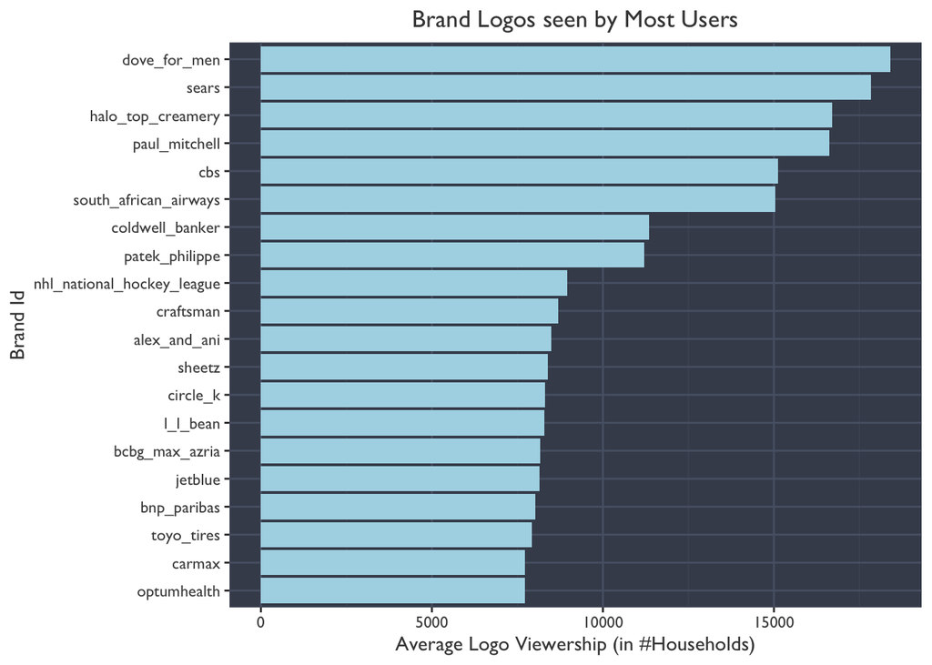

```r
highest_reach_plot <- brand_tbl %>%
  arrange(desc(mean_number_households)) %>%
  slice(1:20) %>%
  ggplot(aes(x= fct_reorder(brand_id, mean_number_households), y = mean_number_households)) +
  geom_bar(stat = "identity", fill = "lightblue") +
  xlab("Brand Id") +
  ylab("Average Logo Viewership (in #Households)") +
  ggtitle("Brand Logos seen by Most Users") +
  theme(plot.title = element_text(hjust = 0.5),
        text = element_text(family = 'Gill Sans', color = "#444444"),
        panel.background = element_rect(fill = '#444B5A'),
        panel.grid.minor = element_line(color = '#4d5566'),
        panel.grid.major = element_line(color = '#586174'),
        legend.position = "none") +
  coord_flip()
highest_reach_plot
```

```r
# Test Correlation of #Households and Brand Prominence
cor(data$number_households, data$brand_prominence)
```

```
## [1] 0.001807671
```

1. Dove_for_men, sears, halo_top_creamery, paul_mitchell, cbs, and south_african_airways are the brands whose logos were seen by > 15.000 households
2. High logo viewership doesn’t directly relate to high brand prominence (correlation = 0.0018)

#### 3. Which TV Shows leads to best user viewership (facet brand prominence)?

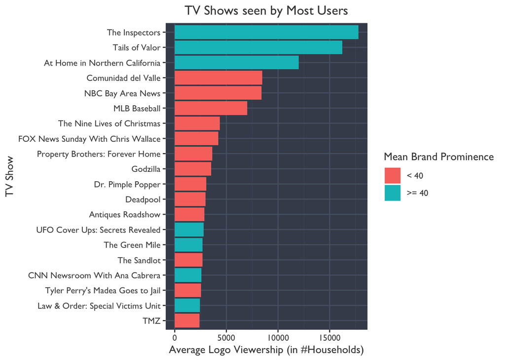

```r
show_viewership_plot <- data %>%
  group_by(show_display_name) %>%
  summarise(mean_brand_prominence = ifelse(mean(brand_prominence) >= 40, '>= 40', '< 40'),
            mean_number_households = mean(number_households)) %>%
  arrange(desc(mean_number_households)) %>%
  slice(1:20) %>%
  ggplot(aes(x= fct_reorder(show_display_name, mean_number_households), y = mean_number_households,
             fill = mean_brand_prominence)) +
  geom_bar(stat = "identity") +
  xlab("TV Show") +
  ylab("Average Logo Viewership (in #Households)") +
  ggtitle("TV Shows seen by Most Users") +
  guides(fill=guide_legend(title = "Mean Brand Prominence")) +
  theme(plot.title = element_text(hjust = 0.5),
        text = element_text(family = 'Gill Sans', color = "#444444"),
        panel.background = element_rect(fill = '#444B5A'),
        panel.grid.minor = element_line(color = '#4d5566'),
        panel.grid.major = element_line(color = '#586174')) +
  coord_flip()
show_viewership_plot
```

The Inspectors and Tails of Valor have both > 40 average brand prominence and > 15,000 households viewership

#### 4. Optimal Number of logos in a single frame for brand prominence

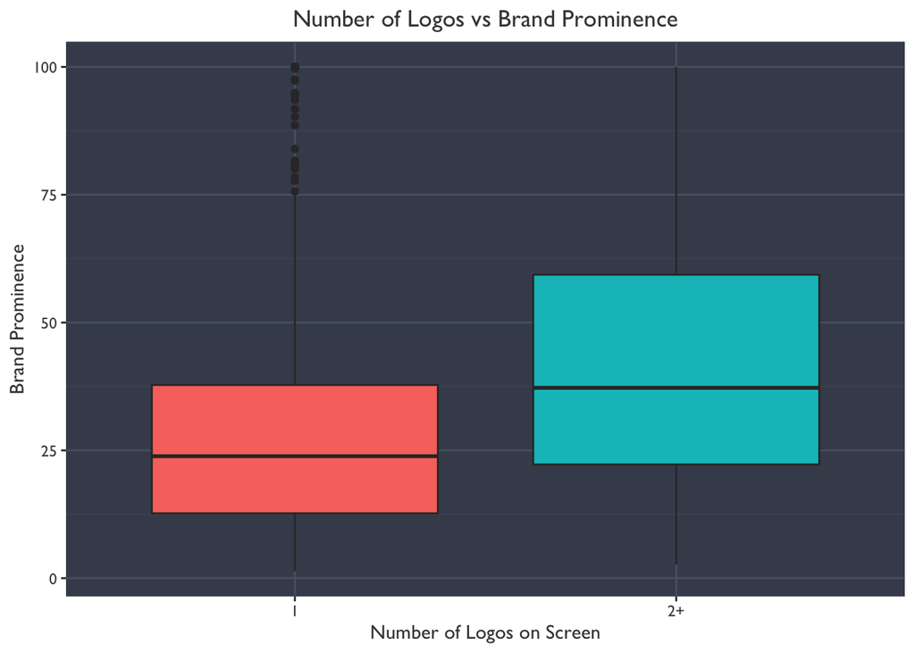

```r
logos_plot <- data %>%
  group_by(modified_number_logos_on_screen) %>%
  sample_n(1000) %>%
  ggplot(aes(x= modified_number_logos_on_screen, y = brand_prominence, fill= modified_number_logos_on_screen)) +
  geom_boxplot() +
  xlab("Number of Logos on Screen") +
  ylab("Brand Prominence") +
  ggtitle("Number of Logos vs Brand Prominence") +
  theme(plot.title = element_text(hjust = 0.5),
        text = element_text(family = 'Gill Sans', color = "#444444"),
        panel.background = element_rect(fill = '#444B5A'),
        panel.grid.minor = element_line(color = '#4d5566'),
        panel.grid.major = element_line(color = '#586174'),
        legend.position = "none")
logos_plot
```

```r
# Testing significance of number_logos_on_screen (using original number of logos instead of modified for linear regression)
summary(lm(brand_prominence ~ number_logos_on_screen, data))
```

```
##
## Call:
## lm(formula = brand_prominence ~ number_logos_on_screen, data = data)
##
## Residuals:
##     Min      1Q  Median      3Q     Max
## -76.961 -16.837  -5.123   9.453  70.929
##
## Coefficients:
##                        Estimate Std. Error t value Pr(>|t|)
## (Intercept)             23.2436     0.3562   65.25   <2e-16 ***
## number_logos_on_screen   5.8271     0.2816   20.70   <2e-16 ***
## ---
## Signif. codes:  0 '***' 0.001 '**' 0.01 '*' 0.05 '.' 0.1 ' ' 1
##
## Residual standard error: 23.13 on 19998 degrees of freedom
## Multiple R-squared:  0.02097,    Adjusted R-squared:  0.02092
## F-statistic: 428.3 on 1 and 19998 DF,  p-value: < 2.2e-16
```

While the analysis suggests that the Brand Prominence faces a significant increase with 2+ logos in the same frame, the data does not have adequate number of samples (just around ~1000 for the 2+ category as opposed to ~18,000 for the 1 category) and so, this particular plot should not be directly inferred from.

However, Number of logos in a single frame does seem to significantly impact brand prominence (P-value < 2e-16) so additional data is required to arrive at an optimal number of logos in a single frame for brand prominence.

#### 5. Brand Exposure Analysis

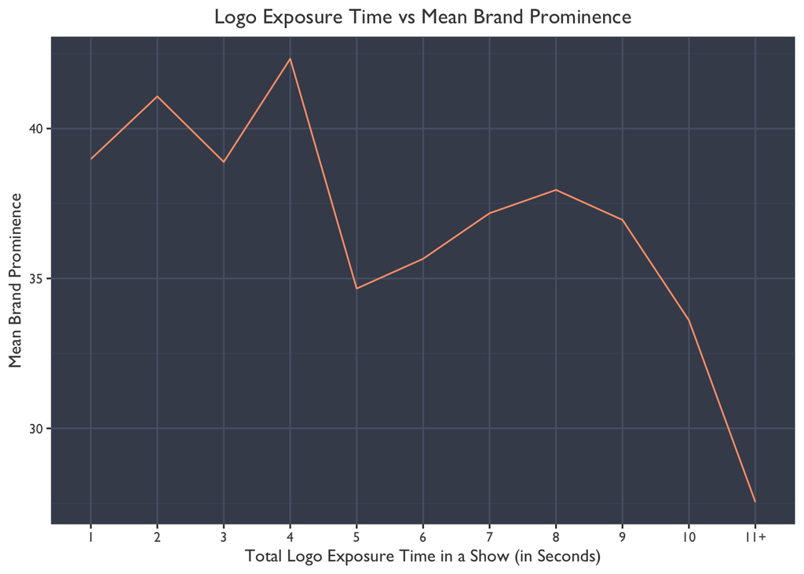

```r
brand_exposure_tbl <- data %>%
  group_by(show_display_name, brand_id) %>%
  summarise(exposure_count = factor(ifelse(sum(on_screen_duration) > 10, '11+', sum(on_screen_duration))),
            mean_brand_prominence = mean(brand_prominence)) %>% # Total exposure duration of logos
  ungroup() %>%
  group_by(exposure_count) %>%
  summarise(mean_brand_prominence = mean(mean_brand_prominence))

brand_exposure_tbl['exposure_count'] <- factor(brand_exposure_tbl$exposure_count,
                                              levels(brand_exposure_tbl$exposure_count)[c(2, 1, 3, 4, 7, 6, 9, 11, 8, 10, 5)])

brand_exposure_plot <- brand_exposure_tbl %>%
  ggplot(aes(x = exposure_count, y = mean_brand_prominence, group = 1)) +
  geom_line(color = "lightsalmon") +
  xlab("Total Logo Exposure Time in a Show (in Seconds)") +
  ylab("Mean Brand Prominence") +
  ggtitle("Logo Exposure Time vs Mean Brand Prominence") +
  theme(plot.title = element_text(hjust = 0.5),
        text = element_text(family = 'Gill Sans', color = "#444444"),
        panel.background = element_rect(fill = '#444B5A'),
        panel.grid.minor = element_line(color = '#4d5566'),
        panel.grid.major = element_line(color = '#586174'),
        legend.position = "none")
brand_exposure_plot
```

```r
# Testing significance of mean_brand_prominence (Using Wilcox sice it's a categorical variable with non-normally distributed samples)
wilcox.test(brand_exposure_tbl$mean_brand_prominence)
```

```
##
##  Wilcoxon signed rank test
##
## data:  brand_exposure_tbl$mean_brand_prominence
## V = 66, p-value = 0.0009766
## alternative hypothesis: true location is not equal to 0
```

**Recommendation:** Research suggests that exposing logos for an extended period of time generates much better value for brands but equal emphasis must be placed on brand prominence as well to reap the best benefits

# Network Related Analysis

#### 6. Which networks have the most logo-viewership? (Competitor analysis)

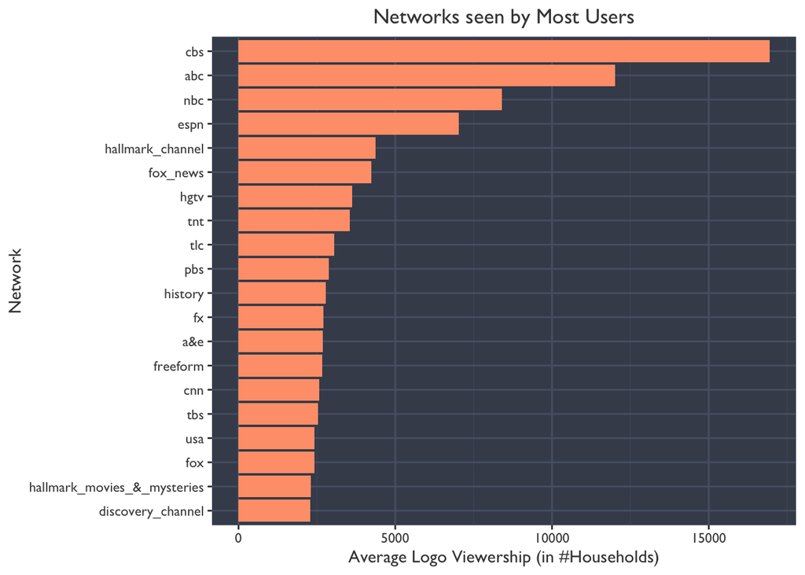

```r
network_tbl <- data %>%
  group_by(network_group_id) %>%
  summarise(mean_brand_prominence = round(mean(brand_prominence),2),
            mean_number_households = round(mean(number_households), 2)) %>%
  arrange(desc(mean_number_households), desc(mean_brand_prominence)) %>%
  slice(1:20)

network_reach_plot <- network_tbl %>%
  ggplot(aes(x= fct_reorder(network_group_id, mean_number_households), y = mean_number_households)) +
  geom_bar(stat = "identity", fill = "lightsalmon") +
  xlab("Network") +
  ylab("Average Logo Viewership (in #Households)") +
  ggtitle("Networks seen by Most Users") +
  guides(fill=guide_legend(title = "Mean Brand Prominence")) +
  theme(plot.title = element_text(hjust = 0.5),
        text = element_text(family = 'Gill Sans', color = "#444444"),
        panel.background = element_rect(fill = '#444B5A'),
        panel.grid.minor = element_line(color = '#4d5566'),
        panel.grid.major = element_line(color = '#586174')) +
  coord_flip()
network_reach_plot
```

Cbs and Abs have the best logo-viewership ( > 10,000 households)

#### 7. Which genres bring in the most viewership?

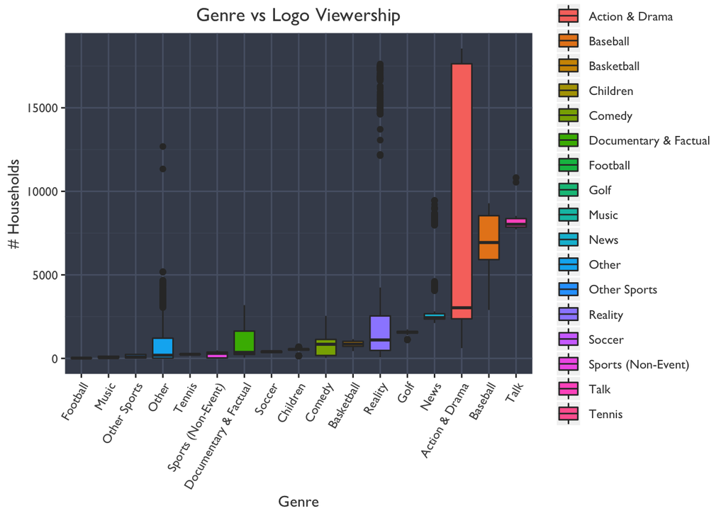

```r
genre_table <- data %>%
  group_by(show_genre) %>%
  summarise(mean_brand_prominence = mean(brand_prominence),
            mean_number_households = mean(number_households)) %>%
  arrange(desc(mean_number_households))

# Boxplot of Genres
genre_plot <- data %>%
  ggplot(aes(x= fct_reorder(show_genre, number_households), y = number_households, fill=show_genre)) +
  geom_boxplot(aes(middle = mean(number_households))) +
  xlab("Genre") +
  ylab("# Households") +
  ggtitle("Genre vs Logo Viewership") +
  guides(fill=guide_legend(title = "Genre")) +
  theme(plot.title = element_text(hjust = 0.5),
        axis.text.x = element_text(angle = 60, hjust = 1),
        text = element_text(family = 'Gill Sans', color = "#444444"),
        panel.background = element_rect(fill = '#444B5A'),
        panel.grid.minor = element_line(color = '#4d5566'),
        panel.grid.major = element_line(color = '#586174'))
genre_plot
```

```r
# Anova analysis on Genre
summary(aov(number_households ~ show_genre, data))
```

```
##                Df    Sum Sq   Mean Sq F value Pr(>F)
## show_genre     16 6.117e+10 3.823e+09    1227 <2e-16 ***
## Residuals   19983 6.228e+10 3.116e+06
## ---
## Signif. codes:  0 '***' 0.001 '**' 0.01 '*' 0.05 '.' 0.1 ' ' 1
```

1. Talk, Baseball, and Action & Drama shows have the best average viewership with Action & Drama having an unusually large variance and Reality shows having outliers with really high viewership.
2. Genre significantly impacts Viewership (P-value < 2e-16)

**Recommendation:** Networks could concentrate on investing in shows that fall in the above-mentioned Genres in order to attract advertisers